# FML ASSIGNMENT 4

```r
#K-Means Cluster Analysis- Fit the data with 5 clusters
fit<-kmeans(pharma2,5)

#Finding the mean value of all quantitative variables for each cluster
aggregate(pharma2,by=list(fit$cluster),FUN=mean)
```

```
##   Group.1  Market_Cap       Beta   PE_Ratio        ROE        ROA
## 1       1  0.07576815 -0.5350964 -0.3338536  0.3627072  0.4765127
## 2       2 -0.90905697  1.4110965 -0.2613021 -0.7063477 -1.1114156
## 3       3 -0.57238455 -0.6220844  0.8692748 -0.7381675 -0.7242993
## 4       4  1.14422955 -0.1780563 -0.1550295  0.4245789  0.9494460
## 5       5  1.75995500 -0.1001567 -0.2858266  1.8862982  1.7355802
##   Asset_Turnover   Leverage  Rev_Growth Net_Profit_Margin
## 1  -7.687760e-02 -0.1737009 -0.86809028         0.7982409
## 2  -1.014784e+00  1.0319661  0.27018076        -0.6941793
## 3  -2.442491e-16 -0.2991312  0.36829509        -0.8069490
## 4   1.230042e+00 -0.5875356  0.04848824         0.1480374
## 5   9.225312e-01 -0.4296811  0.93534886         1.1360419
```

```r
pharma3<-data.frame(pharma2,fit$cluster)
pharma3
```

```
##      Market_Cap        Beta    PE_Ratio         ROE        ROA Asset_Turnover
## ABT   0.1840960 -0.80125356 -0.04671323  0.04009035  0.2416121  -5.121077e-16
## AGN  -0.8544181 -0.45070513  3.49706911 -0.85483986 -0.9422871   9.225312e-01
## AHM  -0.8762600 -0.25595600 -0.29195768 -0.72225761 -0.5100700   9.225312e-01
## AZN   0.1702742 -0.02225704 -0.24290879  0.10638147  0.9181259   9.225312e-01
## AVE  -0.1790256 -0.80125356 -0.32874435 -0.26484883 -0.5664461  -4.612656e-01
## BAY  -0.6953818  2.27578267  0.14948233 -1.45146000 -1.7127612  -4.612656e-01
## BMY  -0.1078688 -0.10015669 -0.70887325  0.59693581  0.8617498   9.225312e-01
## CHTT -0.9767669  1.26308721  0.03299122 -0.11237924 -1.1677918  -4.612656e-01
## ELN  -0.9704532  2.15893320 -1.34037772 -0.70899938 -1.0174553  -1.845062e+00
## LLY   0.2762415 -1.34655112  0.14948233  0.34502953  0.5610770  -4.612656e-01
## GSK   1.0999201 -0.68440408 -0.45749769  2.45971647  1.8389364   1.383797e+00
## IVX  -0.9393967  0.48409069 -0.34100657 -0.29136529 -0.6979905  -4.612656e-01
## JNJ   1.9841758 -0.25595600  0.18013789  0.18593083  1.0872544   9.225312e-01
## MRX  -0.9632863  0.87358895  0.19240011 -0.96753478 -0.9610792  -1.845062e+00
## MRK   1.2782387 -0.25595600 -0.40231769  0.98142435  0.8429577   1.845062e+00
## NVS   0.6654710 -1.30760129 -0.23677768 -0.52338423  0.1288598  -9.225312e-01
## PFE   2.4199899  0.48409069 -0.11415545  1.31287998  1.6322239   4.612656e-01
## PHA  -0.0240846 -0.48965495  1.90298017 -0.81506519 -0.9047030  -4.612656e-01
## SGP  -0.4018812 -0.06120687 -0.40231769 -0.21181593  0.5234929   4.612656e-01
## WPI  -0.9281345 -1.11285216 -0.43297324 -1.03382590 -0.6979905  -9.225312e-01
## WYE  -0.1614497  0.40619104 -0.75792214  1.92938746  0.5422849  -4.612656e-01
##         Leverage  Rev_Growth Net_Profit_Margin fit.cluster
## ABT  -0.21209793 -0.52776752        0.06168225           1
## AGN   0.01828430 -0.38113909       -1.55366706           3
## AHM  -0.40408312 -0.57211809       -0.68503583           3
## AZN  -0.74965647  0.14744734        0.35122600           4
## AVE  -0.31449003  1.21638667       -0.42597037           3
## BAY  -0.74965647 -1.49714434       -1.99560225           2
## BMY  -0.02011273 -0.96584257        0.74744375           1
## CHTT  3.74279705 -0.63276071       -1.24888417           2
## ELN   0.61983791  1.88617085       -0.36501379           2
## LLY  -0.07130879 -0.64814764        1.17413980           1
## GSK  -0.31449003  0.76926048        0.82363947           5
## IVX   1.10620040  0.05603085       -0.71551412           2
## JNJ  -0.62166634 -0.36213170        0.33598685           4
## MRX   0.44065173  1.53860717        0.85411776           2
## MRK  -0.39128411  0.36014907       -0.24310064           4
## NVS  -0.67286239 -1.45369888        1.02174835           1
## PFE  -0.54487226  1.10143723        1.44844440           5
## PHA  -0.30169102  0.14744734       -1.27936246           3
## SGP  -0.74965647 -0.43544591        0.29026942           1
## WPI  -0.49367621  1.43089863       -0.09070919           3
## WYE   0.68383297 -1.17763919        1.49416183           1
```

```r
view(pharma3)
```

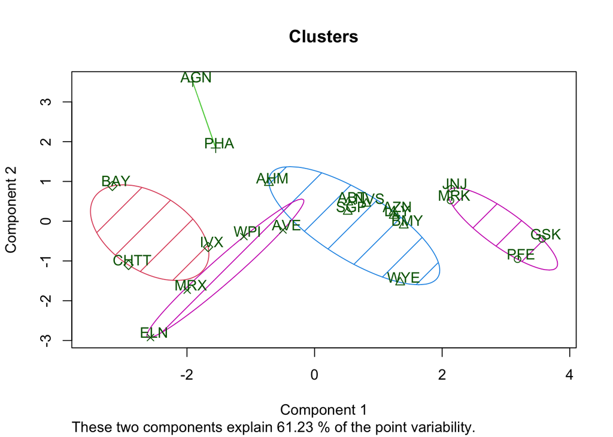

```r
clusplot(pharma2,k5$cluster, main="Clusters" ,shade=TRUE ,color = TRUE, labels = 3,lines = 0)
```

## Manhattan Method

```r
set.seed(69)
k51 = kcca(pharma2, k=5, kccaFamily("kmedians"))
k51
```

```
## kcca object of family 'kmedians'
##
## call:
## kcca(x = pharma2, k = 5, family = kccaFamily("kmedians"))
##
## cluster sizes:
##
## 1 2 3 4 5
## 2 3 6 5 5
```

```r
clusters_index <- predict(k51)
dist(k51@centers)
```

```
##          1        2        3        4
## 2 5.796625
## 3 3.847926 3.569392
## 4 5.559563 3.121363 3.249042
## 5 2.925045 3.649894 1.859338 3.521639
```

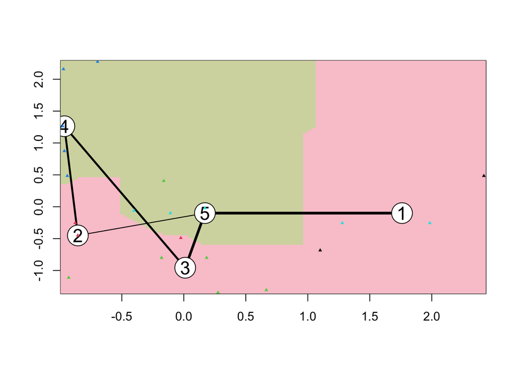

```r
image(k51)
points(pharma2, col=clusters_index,  pch=17, cex=0.5)
```

## QuestionB:#Interpret the clusters with respect to the numerical variables

#used in forming the clusters.

```r
pharma1 %>% mutate(Cluster = k5$cluster) %>% group_by(Cluster) %>% summarise_all("mean")
```

```
## # A tibble: 5 × 10
##   Cluster Market_Cap  Beta PE_Ratio   ROE   ROA Asset_Turnover Leverage
##     <int>      <dbl> <dbl>    <dbl> <dbl> <dbl>          <dbl>    <dbl>
## 1       1     157.   0.48      22.2  44.4 17.7           0.95     0.22
## 2       2      55.8  0.414     20.3  28.7 12.7           0.738    0.371
## 3       3      31.9  0.405     69.5  13.2  5.6           0.75     0.475
## 4       4      13.1  0.598     17.7  14.6  6.2           0.425    0.635
## 5       5       6.64 0.87      24.6  16.5  4.17          0.6      1.65
## # ℹ 2 more variables: Rev_Growth <dbl>, Net_Profit_Margin <dbl>
```

# Cluster 1:High mean values in certain variables suggest a specific profile for Cluster 1.

# Cluster 2:Unique characteristics are indicated by mean values in Cluster 2.

# Cluster 3:Patterns in mean values differentiate Cluster 3 from others.

# Cluster 4:Distinct attributes are reflected in the mean values of Cluster 4.

# Cluster 5:Specific patterns in mean values define the characteristics of Cluster 5.

## Is there a pattern in the clusters with respect to the numerical variables

#(10 to 12)? (those not used in forming the clusters)

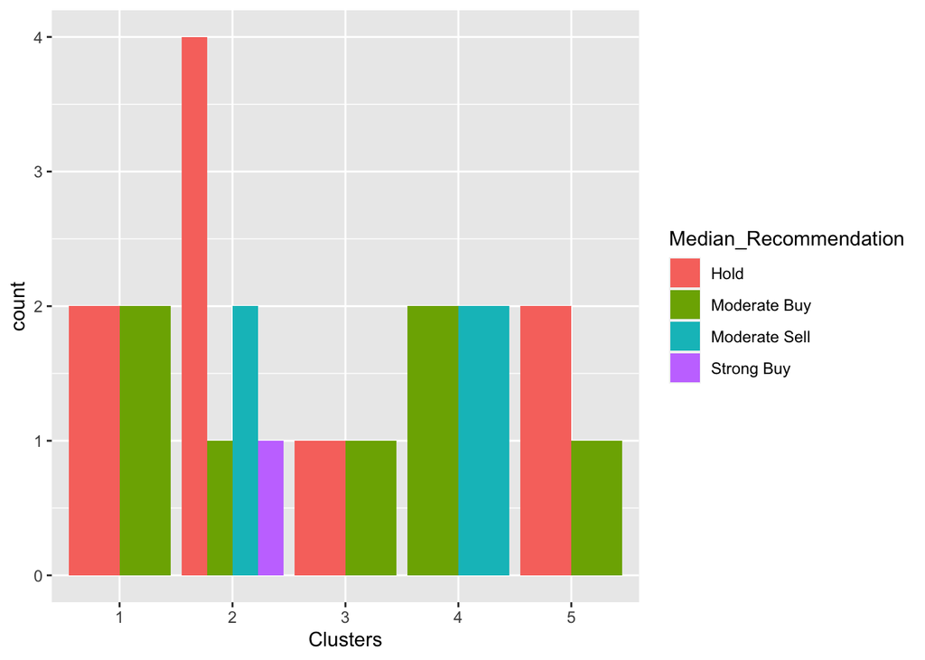

```r
pharma3 <- pharma[10:12] %>% mutate(Clusters=k5$cluster)
ggplot(pharma3, mapping = aes(factor(Clusters), fill =Median_Recommendation))+geom_bar(position='dodge')+labs(x ='Clusters')
```

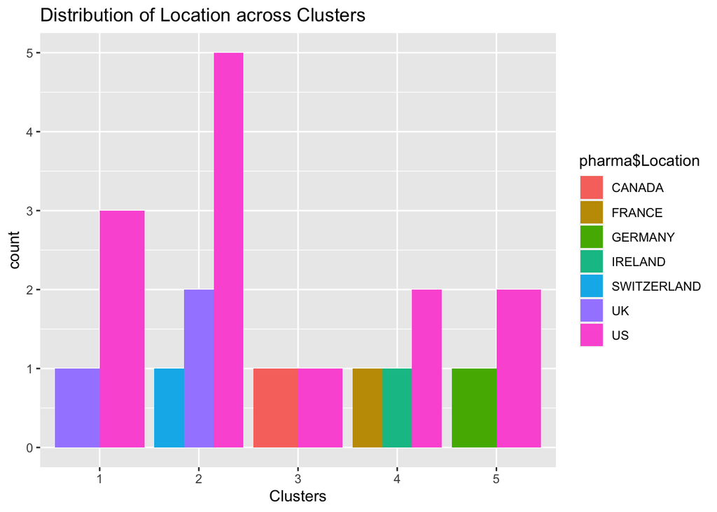

```r
ggplot(pharma3, aes(x = factor(Clusters), fill =pharma$Location)) +
  geom_bar(position = 'dodge') +
  labs(x = 'Clusters') +
  ggtitle('Distribution of Location across Clusters')
```

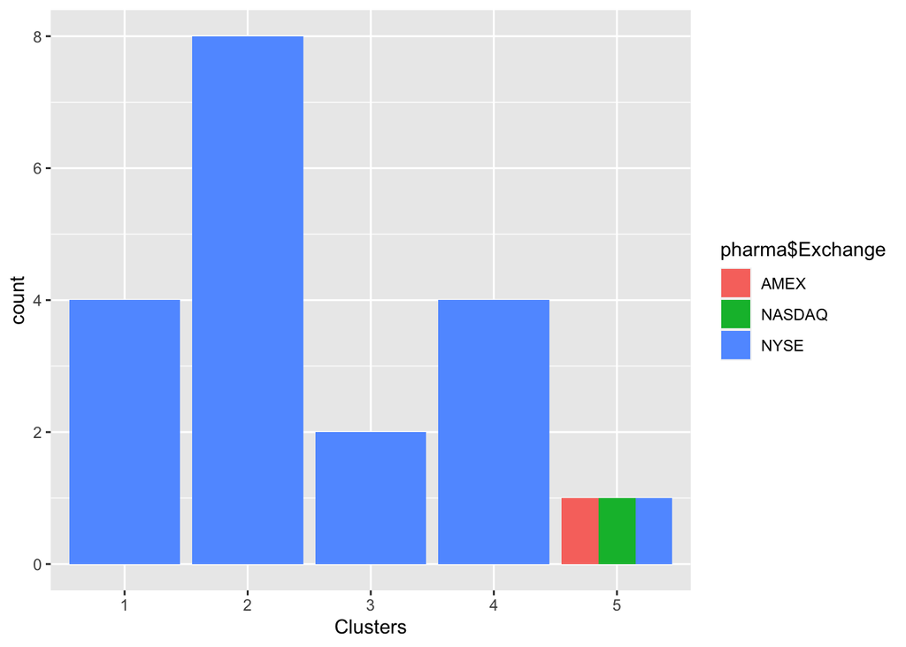

```r
ggplot(pharma3, mapping = aes(factor(Clusters),fill=pharma$Exchange))+geom_bar(position = 'dodge')+labs(x ='Clusters')
```